2018 Edition

# Challenge: What is the future selling price of a home?

A home is often the largest and most expensive purchase a person makes in his or her lifetime. Ensuring homeowners have a trusted way to monitor this asset is incredibly important.

In this competition, students are required to develop a full-fledged approach to make predictions about the future sale prices of homes. A full-fledged approach constist, at least, in the following steps:

- Descriptive statistics about the data
- Data cleaning and pre-processing
- Defining a modeling approach to the problem
- Build such a statistical model
- Validate the outcome of the model

Now, should you ask a home buyer to describe their dream house, they probably wouldn't begin with describing features such as the height of the basement ceiling or the proximity to a railroad. As you will see, the dataset we use in this competition proves that many more features influence price negotiations than the number of bedrooms or a white-picket fence.

With 79 explanatory variables describing (almost) every aspect of residential homes in a small city in the US, this competition challenges you to predict the final price of each home.

# The dataset

## File descriptions

- train.csv - the training dataset
- test.csv - the test dataset
- data_description.txt - full description of each column

## Data fields

Here's a brief version of what you'll find in the data description file.

- SalePrice - the property's sale price in dollars. This is the target variable that you're trying to predict.
- MSSubClass: The building class
- MSZoning: The general zoning classification
- LotFrontage: Linear feet of street connected to property
- LotArea: Lot size in square feet
- Street: Type of road access
- Alley: Type of alley access
- LotShape: General shape of property
- LandContour: Flatness of the property
- Utilities: Type of utilities available
- LotConfig: Lot configuration
- LandSlope: Slope of property
- Neighborhood: Physical locations within Ames city limits
- Condition1: Proximity to main road or railroad
- Condition2: Proximity to main road or railroad (if a second is present)
- BldgType: Type of dwelling
- HouseStyle: Style of dwelling
- OverallQual: Overall material and finish quality
- OverallCond: Overall condition rating
- YearBuilt: Original construction date
- YearRemodAdd: Remodel date
- RoofStyle: Type of roof
- RoofMatl: Roof material
- Exterior1st: Exterior covering on house
- Exterior2nd: Exterior covering on house (if more than one material)
- MasVnrType: Masonry veneer type
- MasVnrArea: Masonry veneer area in square feet
- ExterQual: Exterior material quality
- ExterCond: Present condition of the material on the exterior
- Foundation: Type of foundation
- BsmtQual: Height of the basement
- BsmtCond: General condition of the basement
- BsmtExposure: Walkout or garden level basement walls
- BsmtFinType1: Quality of basement finished area
- BsmtFinSF1: Type 1 finished square feet
- BsmtFinType2: Quality of second finished area (if present)
- BsmtFinSF2: Type 2 finished square feet
- BsmtUnfSF: Unfinished square feet of basement area
- TotalBsmtSF: Total square feet of basement area
- Heating: Type of heating
- HeatingQC: Heating quality and condition
- CentralAir: Central air conditioning
- Electrical: Electrical system
- 1stFlrSF: First Floor square feet
- 2ndFlrSF: Second floor square feet
- LowQualFinSF: Low quality finished square feet (all floors)
- GrLivArea: Above grade (ground) living area square feet
- BsmtFullBath: Basement full bathrooms
- BsmtHalfBath: Basement half bathrooms
- FullBath: Full bathrooms above grade
- HalfBath: Half baths above grade
- Bedroom: Number of bedrooms above basement level
- Kitchen: Number of kitchens
- KitchenQual: Kitchen quality
- TotRmsAbvGrd: Total rooms above grade (does not include bathrooms)
- Functional: Home functionality rating
- Fireplaces: Number of fireplaces
- FireplaceQu: Fireplace quality
- GarageType: Garage location
- GarageYrBlt: Year garage was built
- GarageFinish: Interior finish of the garage
- GarageCars: Size of garage in car capacity
- GarageArea: Size of garage in square feet
- GarageQual: Garage quality
- GarageCond: Garage condition
- PavedDrive: Paved driveway
- WoodDeckSF: Wood deck area in square feet
- OpenPorchSF: Open porch area in square feet
- EnclosedPorch: Enclosed porch area in square feet
- 3SsnPorch: Three season porch area in square feet
- ScreenPorch: Screen porch area in square feet
- PoolArea: Pool area in square feet
- PoolQC: Pool quality
- Fence: Fence quality
- MiscFeature: Miscellaneous feature not covered in other categories
- MiscVal: Value (in dollars) of miscellaneous feature
- MoSold: Month Sold
- YrSold: Year Sold
- SaleType: Type of sale
- SaleCondition: Condition of sale

# Goal of the challenge

It is your job to predict the sales price for each house. For each Id in the test set, you must predict the value of the SalePrice variable.

## Metric

Notebooks are evaluated on Root-Mean-Squared-Error (RMSE) between the logarithm of the predicted value and the logarithm of the observed sales price. (Taking logs means that errors in predicting expensive houses and cheap houses will affect the result equally.)

## Submission File Format

The file should contain a header and have the following format:

```
Id,SalePrice
1461,169000.1
1462,187724.1233
1463,175221
etc.
```

You will find an example submission file within the data directory in the repository.

# Grading the notebook

This challenge is going to be graded as a regular notebook for the AML labs. As a consequence, students should submit:

- the html version of the notebook, using the Data Science Labs submission website, as usual [**Assignement: Challenge Notebook**]
- the submission file (in csv format), that we will use to rank students according to the metric defined above, again through the Data Science Labs submission website [**Assignement: Challenge Predictions**]

In summary, you will have to submit 2 files!

# Content Table

```python
import numpy as np
import pandas as pd
import matplotlib
import matplotlib.pyplot as plt
%matplotlib inline

import warnings
warnings.filterwarnings('ignore')
import seaborn as sns
sns.set(color_codes=True)
import xgboost as xgb
import category_encoders as ce
import sklearn
import scipy
from sklearn.grid_search import GridSearchCV
from sklearn.model_selection import train_test_split
from sklearn.linear_model import LassoCV
from sklearn.cross_validation import cross_val_score
from sklearn import linear_model, preprocessing
from sklearn.metrics import mean_squared_error, r2_score, accuracy_score
from scipy import stats
from scipy.stats import norm, skew
from scipy.cluster import hierarchy as hc
from sklearn.ensemble import RandomForestRegressor
from sklearn.datasets import make_regression
```

## References

https://en.wikipedia.org/wiki/Generalized_linear_model  
https://www.kaggle.com/c/house-prices-advanced-regression-techniques  
**Missing values imputation:**  
http://www.stat.columbia.edu/~gelman/arm/missing.pdf  
**Label encoding of categorical data:**  
https://www.w3schools.com/bootstrap/bootstrap_badges_labels.asp  
https://www.moresteam.com/WhitePapers/download/dummy-variables.pdf  
http://pbpython.com/categorical-encoding.html  
https://stats.idre.ucla.edu/r/library/r-library-contrast-coding-systems-for-categorical-variables/#HELMERT  
**Interesting notebooks:**  
https://www.kaggle.com/erikbruin/house-prices-lasso-xgboost-and-a-detailed-eda  
http://www2.agroparistech.fr/ufr-info/membres/cornuejols/Teaching/Master-ISI/ISI-10/Projets-2016-2017/house_price_prediction(Liu-Wu-Zhu).pdf  
https://github.com/moyphilip/Ames-Housing/blob/master/Ames-Housing-Notebook.ipynb  
**Collapsible Headings extension:**  
https://ndres.me/post/best-jupyter-notebook-extensions/  
**k-fold cross validation:**  
https://machinelearningmastery.com/evaluate-gradient-boosting-models-xgboost-python/  
**XGBoost parameters:**  
http://xgboost.readthedocs.io/en/latest/parameter.html#general-parameters

```python
%%html
#center the figures in the notebook
<style>
.output_png {
    display: table-cell;
    text-align: center;
    vertical-align: middle;
}
</style>
```

#center the figures in the notebook

### I.1 Loading data as a dataframe Go to content Table

To start with, we load train and test data into dataframes `train_df` and `test_df` respectively, using pandas' `read_csv` function.  
The columns of the `train_df` and `test_df` are then sorted alphabetically: leaving the columns `Id` and `SalePrice` untouched.  
Sorting is done in order to make referencing and analysis of data columns simpler during searches which inturn are done during understanding and interpretation.  
We then identify qualitative and quantitative feature columns in the training data.

```python
#base_path = '/root/work/challenge_data/'
base_path = '/mnt/workspace/challenge_data/'
#base_path = '/Users/ramzimissaoui/Documents/ComputerScienceUniverse/Eurecom/cours/2ndSemester/AML/labs2018/challenge/challenge_data/'

train_csv = base_path+"train.csv"
test_csv = base_path+"test.csv"

train_df = pd.read_csv(train_csv)
test_df=pd.read_csv(test_csv)

# Sorting all columns alphabetically, except which Id stays at the beginning and SalePrice which stays at the end
ordered_col_names = ['Id'] + sorted(train_df.columns[1 :-1]) +['SalePrice']
train_df = train_df[[feature for feature in ordered_col_names]]

# Excluding the SalePrice column from the ordered list, as test_df does not have SalePrice
test_df = pd.read_csv(test_csv)[[feature for feature in ordered_col_names[:-1]]]
#categorical features columns
qualitative = [f for f in train_df.columns if train_df.dtypes[f] == 'object']
#numerical features columns
quantitative = [f for f in train_df.columns if train_df.dtypes[f] != 'object']
```

Understanding train and test data layouts:

```python
#the size of the training data
print("We have",train_df.shape[0],"training rows")
#the size of the test data
print("We have",test_df.shape[0],"testing rows")
```

```
We have 1200 training rows
We have 260 testing rows
```

```python
#Check if test columns equal train columns
print(test_df.columns == train_df.columns[:-1])
```

```
[ True  True  True  True  True  True  True  True  True  True  True  True
  True  True  True  True  True  True  True  True  True  True  True  True
  True  True  True  True  True  True  True  True  True  True  True  True
  True  True  True  True  True  True  True  True  True  True  True  True
  True  True  True  True  True  True  True  True  True  True  True  True
  True  True  True  True  True  True  True  True  True  True  True  True
  True  True  True  True  True  True  True  True]
```

### I.2 Data inspection Go to content Table

Displaying a sample of 5 records from the train dataset:

```python
#display data samples
train_df.head(5)
```

|  | Id | 1stFlrSF | 2ndFlrSF | 3SsnPorch | Alley | BedroomAbvGr | BldgType | BsmtCond | BsmtExposure | BsmtFinSF1 | ... | ScreenPorch | Street | TotRmsAbvGrd | TotalBsmtSF | Utilities | WoodDeckSF | YearBuilt | YearRemodAdd | YrSold | SalePrice |
| --- | --- | --- | --- | --- | --- | --- | --- | --- | --- | --- | --- | --- | --- | --- | --- | --- | --- | --- | --- | --- | --- |
| 0 | 1 | 856 | 854 | 0 | NaN | 3 | 1Fam | TA | No | 706 | ... | 0 | Pave | 8 | 856 | AllPub | 0 | 2003 | 2003 | 2008 | 208500 |
| 1 | 2 | 1262 | 0 | 0 | NaN | 3 | 1Fam | TA | Gd | 978 | ... | 0 | Pave | 6 | 1262 | AllPub | 298 | 1976 | 1976 | 2007 | 181500 |
| 2 | 3 | 920 | 866 | 0 | NaN | 3 | 1Fam | TA | Mn | 486 | ... | 0 | Pave | 6 | 920 | AllPub | 0 | 2001 | 2002 | 2008 | 223500 |
| 3 | 4 | 961 | 756 | 0 | NaN | 3 | 1Fam | Gd | No | 216 | ... | 0 | Pave | 7 | 756 | AllPub | 0 | 1915 | 1970 | 2006 | 140000 |
| 4 | 5 | 1145 | 1053 | 0 | NaN | 4 | 1Fam | TA | Av | 655 | ... | 0 | Pave | 9 | 1145 | AllPub | 192 | 2000 | 2000 | 2008 | 250000 |

5 rows × 81 columns

Obtaining the list of feature columns present in the train and test set:

```python
#data columns
print("The training data contains", train_df.columns.size,"columns")
print("The test data contains", test_df.columns.size,"columns","\n")

print ("{: ^100s}".format("The column names - train_df"))
print ("{: ^100s}".format("--------------------"))
print (', '.join(list(train_df.columns)))
print("\n")
print ("{: ^100s}".format("The column names - test_df"))
print ("{: ^100s}".format("--------------------"))
print (', '.join(list(test_df.columns)))
```

```
The training data contains 81 columns
The test data contains 80 columns

                                    The column names - train_df
                                        --------------------
Id, 1stFlrSF, 2ndFlrSF, 3SsnPorch, Alley, BedroomAbvGr, BldgType, BsmtCond, BsmtExposure, BsmtFinSF1, BsmtFinSF2, BsmtFinType1, BsmtFinType2, BsmtFullBath, BsmtHalfBath, BsmtQual, BsmtUnfSF, CentralAir, Condition1, Condition2, Electrical, EnclosedPorch, ExterCond, ExterQual, Exterior1st, Exterior2nd…


                                     The column names - test_df
                                        --------------------
Id, 1stFlrSF, 2ndFlrSF, 3SsnPorch, Alley, BedroomAbvGr, BldgType, BsmtCond, BsmtExposure, BsmtFinSF1, BsmtFinSF2, BsmtFinType1, BsmtFinType2, BsmtFullBath, BsmtHalfBath, BsmtQual, BsmtUnfSF, CentralAir, Condition1, Condition2, Electrical, EnclosedPorch, ExterCond, ExterQual, Exterior1st, Exterior2nd…
```

**Understanding the effect of feature columns on `SalePrice`:**  
We begin by understanding the datatype of columns as either numerical (quantitative: `int64` or `float64`) or categorical (qualitative: `object`).  
In order to further analyze `SalePrice` as a function of these features, we maintain these two types of columns in separate dataframes: `numerical_df` and `categorical_df`.

```python
train_df.dtypes.value_counts()
floats_train_df = train_df.select_dtypes(include=['float64'])
print('Columns of datatype float64 are:\n', floats_train_df.columns)
```

```
Columns of datatype float64 are:
 Index(['GarageYrBlt', 'LotFrontage', 'MasVnrArea'], dtype='object')
```

COMMENT:

Although the columns ['`GarageYrBlt`', '`LotFrontage`', '`MasVnrArea`'] are actually integers in the given dataset (understood by observing the training data file), their datatype in the dataframe is `float64`.  
This is because, these columns have `NA` as value for certain houses.  
In pandas dataframes, integer columns cannot have `NA` as values; therefore these are automatically typed to be `float64`.

```python
#Selecting only the numerical columns
numerical_df = train_df.select_dtypes(include=['float64','int64'])

# Categorical Features DF
# Object Features
categorical_features = train_df.dtypes[train_df.dtypes == 'object'].index
categorical_df = train_df[categorical_features]
```

```python
# Printing Numerical Columns
print("We have", numerical_df.columns.size,"numerical columns")
print ("{: ^100s}".format("The numerical columns names"))
print ("{: ^100s}".format("--------------------"))
print (', '.join(list(numerical_df.columns)))

# Printing Categorical Columns
print("\n\nWe have", categorical_df.columns.size,"categorical columns")
print ("{: ^100s}".format("The categorical columns names"))
print ("{: ^100s}".format("--------------------"))
print (', '.join(list(categorical_df.columns)))
```

```
We have 38 numerical columns
                                    The numerical columns names
                                        --------------------
Id, 1stFlrSF, 2ndFlrSF, 3SsnPorch, BedroomAbvGr, BsmtFinSF1, BsmtFinSF2, BsmtFullBath, BsmtHalfBath, BsmtUnfSF, EnclosedPorch, Fireplaces, FullBath, GarageArea, GarageCars, GarageYrBlt, GrLivArea, HalfBath, KitchenAbvGr, LotArea, LotFrontage, LowQualFinSF, MSSubClass, MasVnrArea, MiscVal, MoSold, Op…


We have 43 categorical columns
                                   The categorical columns names
                                        --------------------
Alley, BldgType, BsmtCond, BsmtExposure, BsmtFinType1, BsmtFinType2, BsmtQual, CentralAir, Condition1, Condition2, Electrical, ExterCond, ExterQual, Exterior1st, Exterior2nd, Fence, FireplaceQu, Foundation, Functional, GarageCond, GarageFinish, GarageQual, GarageType, Heating, HeatingQC, HouseStyle,…
```

INFERENCE:

Our training data contains 81 columns among them we have 38 of numerical type

We can trust the training data as their columns are equal to those of the training data.

### I.3 Descriptive statistics Go to content Table

# The target: `SalePrice`

Descriptive statistics of `SalePrice`:

```python
#statistics about 'SalePrice'
train_df['SalePrice'].describe()
```

```
count      1200.000000
mean     181414.628333
std       81070.908544
min       34900.000000
25%      129900.000000
50%      163700.000000
75%      214000.000000
max      755000.000000
Name: SalePrice, dtype: float64
```

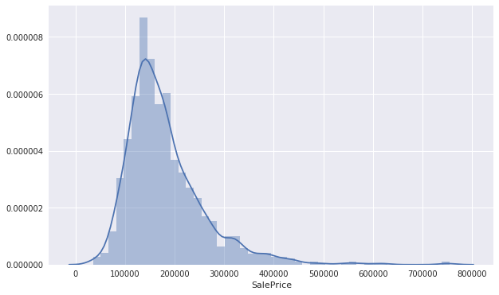

```python
#histogram
#sns.distplot(train_df['SalePrice'])
sp_df=train_df['SalePrice']
a4_dims = (10, 6)
fig, ax = plt.subplots(figsize=a4_dims)

#histogram of the SalePrice without log transformation
sns.distplot(sp_df,ax=ax);
```

```python
# Skewness and Kurtosis
print("Skewness: %f" % train_df['SalePrice'].skew())
print("Kurtosis: %f" % train_df['SalePrice'].kurt())
```

```
Skewness: 1.967215
Kurtosis: 7.033907
```

INFERENCE:

```
 mu = 12.02 and sigma = 0.40
```

```
Text(0.5,1,'SalePrice distribution')
```

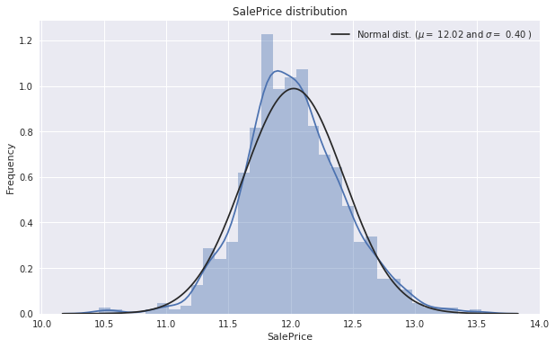

```python
#histogram
#sns.distplot(train_df['SalePrice'])
sp_df=np.log(train_df['SalePrice'])
a4_dims = (10, 6)
fig, ax = plt.subplots(figsize=a4_dims)

#histogram of the SalePrice with log transformation
sns.distplot(sp_df,ax=ax, fit=norm);

# Get the fitted parameters used by the function
(mu, sigma) = norm.fit(sp_df)
print( '\n mu = {:.2f} and sigma = {:.2f}\n'.format(mu, sigma))

#Now plot the distribution
plt.legend(['Normal dist. ($\mu=$ {:.2f} and $\sigma=$ {:.2f} )'.format(mu, sigma)],
            loc='best')
plt.ylabel('Frequency')
plt.title('SalePrice distribution')
```

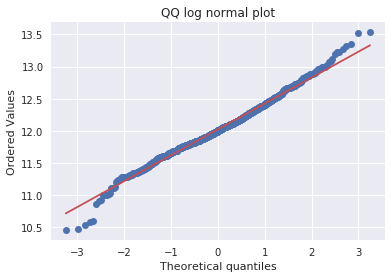

```python
#See also the QQ-plot
fig = plt.figure()
res = stats.probplot(sp_df, plot=plt)
plt.title("QQ log normal plot")
plt.show()
```

Analysis of Columns with Numerical Values:

Certain columns/features that are considered as numerical are not intrinsically numerical by usage.  
As an example, consider the column: `MSSubClass`: which identifies the type of dwelling involved in the sale.  
The possible values for this column and their corresponding meaning are:  
20 1-STORY 1946 & NEWER ALL STYLES  
30 1-STORY 1945 & OLDER  
40 1-STORY W/FINISHED ATTIC ALL AGES  
45 1-1/2 STORY - UNFINISHED ALL AGES  
50 1-1/2 STORY FINISHED ALL AGES  
60 2-STORY 1946 & NEWER\  
70 2-STORY 1945 & OLDER\  
75 2-1/2 STORY ALL AGES\  
80 SPLIT OR MULTI-LEVEL\  
85 SPLIT FOYER\  
90 DUPLEX - ALL STYLES AND AGES\  
120 1-STORY PUD (Planned Unit Development) - 1946 & NEWER\  
150 1-1/2 STORY PUD - ALL AGES\  
160 2-STORY PUD - 1946 & NEWER\  
180 PUD - MULTILEVEL - INCL SPLIT LEV/FOYER  
190 2 FAMILY CONVERSION - ALL STYLES AND AGES |  
Therefore it is not logical to consider these numbers as actual integers during computations of covariance. Since these are apparently IDs for each value of the feature, this feature should be considered as categorical.  
The two columns `MSSubClass` and `OverallCond` which existe as numerical columns in the dataset when analysed, are really assigned numbers that represent a category that they belong to or a feature that they comprise of. So, essentially, these columns need to be treated as Categorical and then encoded for further analysis.  
Consider the column `OverallQual`: which rates the overall material and finish of the house. (similarly `OverallCond` which rates the overall condition of the house) The possible values for these two columns are:  
10 Very Excellent  
9 Excellent  
8 Very Good  
7 Good  
6 Above Average  
5 Average  
4 Below Average  
3 Fair  
2 Poor  
1 Very Poor  
These type of features are called ordinal features.  
The values logically measure the quality by ratings. A good rating has a higher numerical value and a bad rating has a lower value. Therefore these can safely be considered for numerical computations of covariance with `SalePrice` as well.

We now analyse the dependencies between features (numerical); more importantly, the relationship of `SalePrice` with features by using a heatmap of the correlation matrix between numerical features.

```
Text(0.5,1,'Heatmap for the correlation matrix between numerical features ')
```

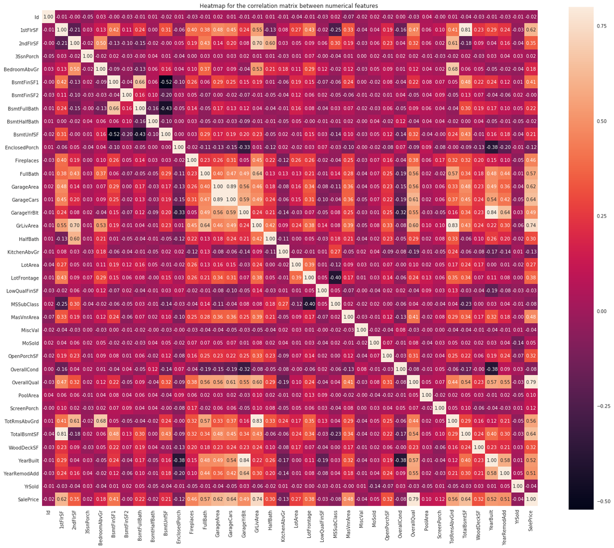

```python
corr_mat = train_df.corr()
imp= corr_mat ['SalePrice']> 0.5

f, ax = plt.subplots(figsize = (24,20))
sns.heatmap(corr_mat, annot=True, fmt='.2f', vmax = 0.8, square=True) #cmap='Blues'
ax.set_title('Heatmap for the correlation matrix between numerical features ')
```

INFERENCE:

Considering features that have a correlation coefficient > 0.5 (which is the correlation coefficient value for a moderate uphill relation) with `SalePrice` as features that significantly affect the `SalePrice`.

Note:

This correlation matrix takes into consideration only columns with numerical values in the given dataset.

```python
# Extracting columns of numerical features that have a correlation coefficient > 0.5 with SalePrice
imp_num_feats = list((corr_mat['SalePrice'] > 0.5)[imp == True].index)

# Excluding the last column: which is SalePrice itself
imp_num_feats=imp_num_feats[:-1]

print ("{: ^100s}".format("Important numerical features that affect the SalePrice are:"))
print ("{: ^100s}".format("--------------------"))
print ('|'.join(list(imp_num_feats)))
print("\n")
print("{: ^100s}".format('Number of important features:'))
print ("{: ^100s}".format("--------------------"))
print("{: ^100s}".format(str(len(imp_num_feats))))
```

```
                    Important numerical features that affect the SalePrice are:
                                        --------------------
1stFlrSF|FullBath|GarageArea|GarageCars|GrLivArea|OverallQual|TotRmsAbvGrd|TotalBsmtSF|YearBuilt|YearRemodAdd


                                   Number of important features:
                                        --------------------
                                                 10
```

INFERENCE:

Among the numerical features, we see that the above list contains most of the features which are in the list of top-10 features that house hunters look for while buying a house.

| `1stFlrSF` | First Floor Square Feet |
| --- | --- |
| `FullBath` | Full Bathrooms above grade |
| `GarageArea` | Size of garage in sq.ft. |
| `GarageCars` | Size of garage in car capacity |
| `GrLivArea` | Above grade (ground) living area sq.ft. |
| `OverallQual` | Rates the overall material and finish of the house |
| `TotRmsAbvGrd` | Total rooms above grade (excluding bathrooms) |
| `TotalBsmtSF` | Total sqft of basement area |
| `YearBuilt` | Original construction date |
| `YearRemodAdd` | Remodel date (same as construction date if no remodeling or additions) |

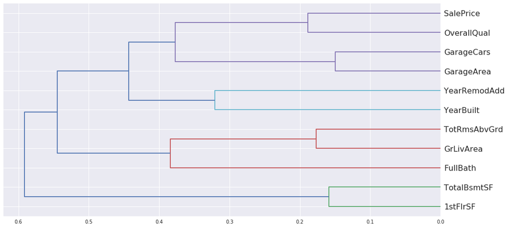

```python
#important features for the dendrogram
imp_features=imp_num_feats+['SalePrice']
#computing the Spearman’s Rank Correlation coefficient
corr=np.round(scipy.stats.spearmanr(train_df[imp_features]).correlation, 4)
corr_condensed=hc.distance.squareform(1-corr)
z=hc.linkage(corr_condensed, method='average')
#plotting the dendrogram
fig=plt.figure(figsize=(16,8))
dendrogram= hc.dendrogram(z, labels=imp_features, orientation='left', leaf_font_size=16)
```

Analysing `SalePrice` as a function of each feature:

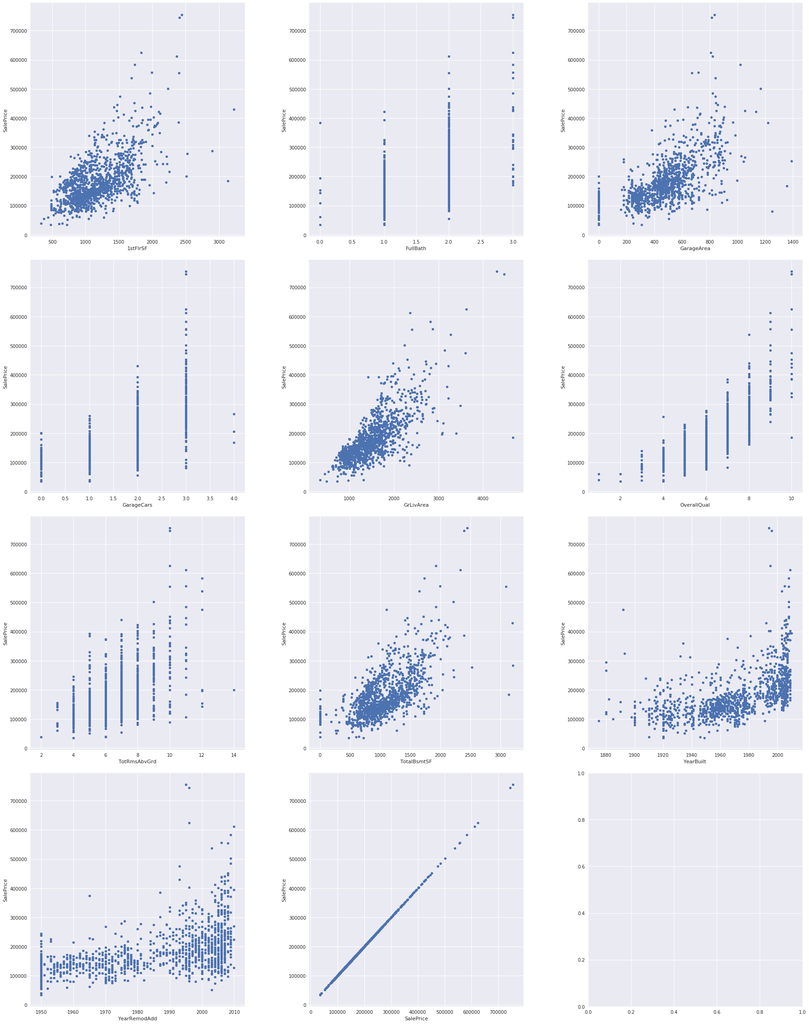

```python
# Scatter plot for the important numerical features identified above
data = train_df[imp_num_feats+['SalePrice']]

fig, axs = plt.subplots(4,3, figsize = (30,40))

fig.subplots_adjust(hspace=.1, wspace=.3)

for k in axs:
    for i,j in zip(data, axs.flat):
        data.plot(x=i, y='SalePrice', kind='scatter', ax=j)

plt.show()
```

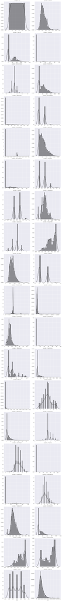

```python
#Another code to plot numerical features
f = pd.melt(train_df, value_vars=quantitative)
g = sns.FacetGrid(f, col="variable",  col_wrap=2, sharex=False, sharey=False, size=6)
g = g.map(sns.distplot, "value", color="black")
```

INFERENCE:

While ganining on regression transformation it will smooth out some irregularities which could be important like large amount of houses with 0 2ndFlrSF. Such irregularities are good candidates for feature construction.  
We will apply the tranformation after filling the NAs later in the notebook.

### II.1 Outliers Go to content Table

Observing the scatter plots for numerical features we noticed that `GrLivArea`has an outlier which has a `SalePrice`less than 200000 and a value greater than 4000.  
Below is the isolated scatter for that numerical feature, after which we further continue the process of identifying the outlier data record for handling it suitably (removal in this case; to prevent the outlier from improperly influencing training/ prediction).

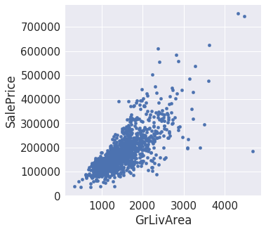

```python
# Scatter plot for TotalSq feature
data = train_df[['GrLivArea','SalePrice']]

fig, axs = plt.subplots(1,1, figsize = (5,5))
data.plot(x='GrLivArea', y='SalePrice', kind='scatter', ax=axs)

plt.show()
```

```python
#identifying the id of the outlier
print(train_df[train_df['GrLivArea']>4000][['GrLivArea','SalePrice']])
```

```
      GrLivArea  SalePrice
523        4676     184750
691        4316     755000
1182       4476     745000
```

the outlier's id is `523`.

```python
#dropping the outlier
train_df=train_df.drop(train_df.index[523])
```

```python
#checking
print(train_df[train_df['GrLivArea']>4000][['GrLivArea','SalePrice']])
```

```
      GrLivArea  SalePrice
691        4316     755000
1182       4476     745000
```

### II.2 Missing Data Go to content Table

#### II.2.1 Statistics and visualization Go to content Table

Identifying and visualizing columns containing `NA`, `Null`in train and test dataframes:

```python
#percentage of missing data in all features in the training data
train_all_columns = (train_df.isnull().sum() / len(train_df)) * 100

#select features that have at least one empty value
train_miss_columns = train_all_columns.drop(train_all_columns[train_all_columns == 0].index).sort_values(ascending=False)
train_missing_data = pd.DataFrame({'train%' :train_miss_columns})

#percentage of missing data in all features in the test data
test_all_columns = (test_df.isnull().sum() / len(test_df)) * 100

#select features that have at least one empty value
test_miss_columns = test_all_columns.drop(test_all_columns[test_all_columns == 0].index).sort_values(ascending=False)
test_missing_data = pd.DataFrame({'test%' :test_miss_columns})

pd.concat([train_missing_data,test_missing_data],axis=1).sort_values(by=['test%','train%'], ascending=False)
```

|  | train% | test% |
| --- | --- | --- |
| PoolQC | 99.666389 | 98.846154 |
| MiscFeature | 96.080067 | 97.307692 |
| Alley | 93.744787 | 93.846154 |
| Fence | 81.067556 | 79.230769 |
| FireplaceQu | 47.039199 | 48.461538 |
| LotFrontage | 17.514595 | 18.846154 |
| GarageCond | 5.587990 | 5.384615 |
| GarageFinish | 5.587990 | 5.384615 |
| GarageQual | 5.587990 | 5.384615 |
| GarageType | 5.587990 | 5.384615 |
| GarageYrBlt | 5.587990 | 5.384615 |
| BsmtExposure | 2.752294 | 1.923077 |
| BsmtFinType2 | 2.752294 | 1.923077 |
| BsmtCond | 2.668891 | 1.923077 |
| BsmtFinType1 | 2.668891 | 1.923077 |
| BsmtQual | 2.668891 | 1.923077 |
| MasVnrArea | 0.500417 | 0.769231 |
| MasVnrType | 0.500417 | 0.769231 |
| Electrical | NaN | 0.384615 |

```
Text(0.5,1,'missing data by feature')
```

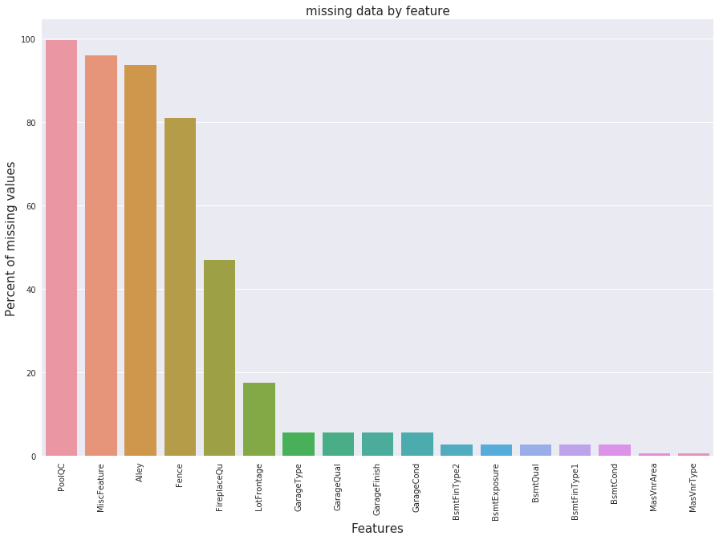

```python
#plot non zero percentage of missing values of train features
f, ax = plt.subplots(figsize=(15, 10))
plt.xticks(rotation='90')
sns.barplot(x=train_miss_columns.index, y=train_miss_columns)
plt.xlabel('Features', fontsize=15)
plt.ylabel('Percent of missing values', fontsize=15)
plt.title('missing data by feature', fontsize=15)
```

#### II.2.2 Cleaning Meaningful NA(s) in categorical columns Go to content Table

```python
#All categorical features with at least one NA
is_NA = categorical_df.isna().any()

#categorical features that have NAs
cat_NA = list(is_NA.index.where(is_NA.values == True).dropna())
print("Categorical features that have NAs : \n", cat_NA)

categorical_df[categorical_df.isna()]='FeatureAbsent'

#Updating train_df
train_df[categorical_features]=categorical_df

#replacing NAs in test_df by featureAbsent
categorical_test_df=test_df[qualitative]
categorical_test_df[categorical_test_df.isna()]='featureAbsent'
test_df[categorical_features]=categorical_test_df
```

[output not shown]

[output not shown]

#### II.2.3 Cleaning Meaningful NA(s) in numerical columns Go to content Table

For `NA`s in numerical columns, cleaning is done by filling the `NA` with the median value of the column over the dataset (for both train and test dataframes) in order to least affect the statistics.

```python
#All numerical features with at least one NA
is_NA = numerical_df.isna().any()

#categorical features that have NAs
num_NA = list(is_NA.index.where(is_NA.values == True).dropna())
print("Numerical features that have NAs : \n", num_NA)

# Handle remaining missing values for numerical features by using median as replacement
train_df = train_df.fillna(train_df.median())
test_df = test_df.fillna(test_df.median())
```

[output not shown]

### II.3 Categorical features visualization Go to content Table

We now move on to visualize categorical data after cleaning.  
Since `NA` replacement was done, we are now able to identify that a significant number of houses actually lack some features.  
Consider the feature `Alley` as an example: a large percentage of houses do not have an `Alley` and for the feature `PoolQC` we can observe that almost none of the houses have this feature!

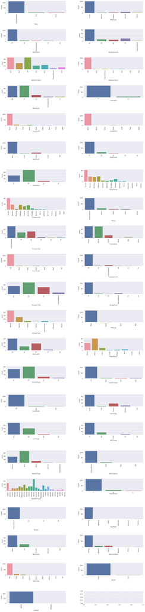

```python
n_rows = 22

fig, axs = plt.subplots(n_rows,2, figsize = (20,90))
fig.subplots_adjust(hspace=1.3, wspace=.3)

for k in axs:
    for i,j in zip(categorical_features, axs.flat):
        g = sns.countplot(x=i, data=categorical_df, ax=j)
        plt.setp(j.get_xticklabels(), rotation=90)
```

COMMENT:

**The graph above represents the count of each categorical feature's values.**

First of all, it allows us to have a better visualization of the values of each categorical feature!

Second of all, we can see if there are missing values and have an overview about its proportion compared to the other values. This is useful especially in the case of `PoolQC` which is an interesting feature to deal with later!

Last but not least, we can easily identify the dominant values and the least present ones (`Utilities`,`Street`, `Electrical` and many other features are in this case!)

We now visualize categorical features with box plots which serve as an efficient mechanism to understand `SalePrice` variations (even incuding the minimum, maximum, median, and quartile values) with respect to feature value.

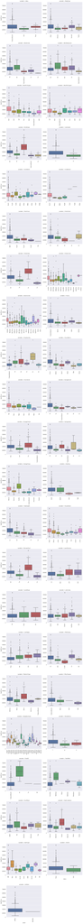

```python
import seaborn as sns
#Another code to plot the categorical features

def boxplot(x, y, **kwargs):
    sns.boxplot(x=x, y=y)
    x=plt.xticks(rotation=90)

f = pd.melt(train_df, id_vars=['SalePrice'], value_vars=qualitative)
g = sns.FacetGrid(f, col="variable",  col_wrap=2, sharex=False, sharey=False, size=6)
g = g.map(boxplot, "value", "SalePrice")
```

INFERENCE:

**The graph above represents the boxplot graphs of each categorical feature.**

The interpretation of the graph is based on the understanding of the boxplot itself.

Given a feature, comparing the respective medians, and comparing their locations, gives us an overview of the average price of houses having this feature value

For each feature, comparing the interquartile ranges, in other terms, the box lengths, allows us to better see and compare the dispersion of the prices between the feature values.

An other way to have an idea about the dispersion is to Look at the overall spread as shown by the adjacent feature values.

An other important aspect about our data is to look for potential outliers, which are represented by the isolated points above the upper adjacent value or below the lower adjacent value of a given feature value

### III.1 Encoding Go to content Table

A categorical variable of K categories is usually entered in a regression analysis as a sequence of K-1 variables, e.g. as a sequence of K-1 dummy variables. Categorical variables (wiki) are those that represent a fixed number of possible values, rather than a continuous number. Each value assigns the measurement to one of those finite groups, or categories. They differ from ordinal variables in that the distance from one category to another ought to be equal regardless of the number of categories, as opposed to ordinal variables which have some intrinsic ordering. 1. Ordinal: low, medium, high 2. Categorical: Georgia, Alabama, South Carolina, New York The machine learning algorithms we will later use tend to want numbers, and not strings, as their inputs so we need some method of coding to convert them.  
Our objective is to code categorical variables into numbers. A straightforward way of doing this is to just assign an integer to each category (assuming we know all of the possible categories up front).  
After trying the below category encoders:  
- Backward Difference  
- Ordinal  
- Dummy  
- Helmert  
- Polynomial  
- Label encoding  
We use a straightforward encoding method Label encoding which simply convert each value in a column to a number.

Label encoder

```python
# Get a new clean dataframe by concatenating train_df and test_df
all_data=pd.concat((train_df.iloc[:,1:-1], test_df.iloc[:,1:]))
obj_df = all_data.copy()


# process columns, apply LabelEncoder to categorical features
for c in obj_df.columns:
    lbl = preprocessing.LabelEncoder()
    lbl.fit(list(obj_df[c].values))
    obj_df[c] = lbl.transform(list(obj_df[c].values))


obj_df.iloc[20:,:].head(20)
```

|  | 1stFlrSF | 2ndFlrSF | 3SsnPorch | Alley | BedroomAbvGr | BldgType | BsmtCond | BsmtExposure | BsmtFinSF1 | BsmtFinSF2 | ... | SaleType | ScreenPorch | Street | TotRmsAbvGrd | TotalBsmtSF | Utilities | WoodDeckSF | YearBuilt | YearRemodAdd | YrSold |
| --- | --- | --- | --- | --- | --- | --- | --- | --- | --- | --- | --- | --- | --- | --- | --- | --- | --- | --- | --- | --- | --- |
| 20 | 357 | 372 | 0 | 0 | 4 | 0 | 4 | 0 | 0 | 0 | ... | 6 | 0 | 1 | 7 | 380 | 0 | 154 | 106 | 56 | 0 |
| 21 | 318 | 0 | 0 | 1 | 3 | 0 | 4 | 4 | 0 | 0 | ... | 8 | 0 | 1 | 4 | 55 | 0 | 0 | 34 | 0 | 1 |
| 22 | 678 | 0 | 0 | 0 | 3 | 0 | 4 | 4 | 0 | 0 | ... | 8 | 0 | 1 | 5 | 658 | 0 | 100 | 103 | 52 | 2 |
| 23 | 281 | 0 | 0 | 0 | 3 | 4 | 4 | 4 | 429 | 0 | ... | 8 | 0 | 1 | 4 | 300 | 0 | 46 | 77 | 26 | 1 |
| 24 | 281 | 0 | 0 | 0 | 3 | 0 | 4 | 3 | 51 | 116 | ... | 8 | 0 | 1 | 4 | 314 | 0 | 239 | 69 | 51 | 4 |
| 25 | 600 | 0 | 0 | 0 | 3 | 0 | 4 | 4 | 0 | 0 | ... | 8 | 0 | 1 | 5 | 585 | 0 | 0 | 108 | 57 | 3 |
| 26 | 163 | 0 | 0 | 0 | 3 | 0 | 4 | 3 | 76 | 90 | ... | 8 | 0 | 1 | 3 | 203 | 0 | 141 | 52 | 50 | 4 |
| 27 | 651 | 0 | 0 | 0 | 3 | 0 | 4 | 4 | 557 | 0 | ... | 8 | 0 | 1 | 5 | 639 | 0 | 0 | 108 | 58 | 4 |
| 28 | 600 | 0 | 0 | 0 | 2 | 0 | 4 | 2 | 573 | 0 | ... | 8 | 0 | 1 | 4 | 551 | 0 | 180 | 58 | 47 | 0 |
| 29 | 6 | 0 | 0 | 0 | 1 | 0 | 4 | 4 | 0 | 0 | ... | 8 | 0 | 1 | 2 | 21 | 0 | 16 | 31 | 0 | 2 |
| 30 | 26 | 128 | 0 | 2 | 3 | 0 | 4 | 4 | 0 | 0 | ... | 8 | 0 | 1 | 4 | 59 | 0 | 0 | 24 | 0 | 2 |
| 31 | 405 | 0 | 0 | 0 | 3 | 0 | 4 | 4 | 0 | 0 | ... | 8 | 0 | 1 | 4 | 420 | 0 | 0 | 67 | 56 | 2 |
| 32 | 408 | 0 | 0 | 0 | 3 | 0 | 4 | 0 | 0 | 0 | ... | 8 | 0 | 1 | 5 | 422 | 0 | 0 | 108 | 57 | 2 |
| 33 | 648 | 0 | 0 | 0 | 4 | 0 | 4 | 4 | 503 | 0 | ... | 8 | 0 | 1 | 4 | 512 | 0 | 0 | 60 | 9 | 4 |
| 34 | 582 | 0 | 0 | 0 | 2 | 4 | 4 | 4 | 538 | 0 | ... | 8 | 0 | 1 | 4 | 582 | 0 | 128 | 106 | 55 | 1 |
| 35 | 336 | 389 | 0 | 0 | 4 | 0 | 4 | 0 | 0 | 0 | ... | 8 | 0 | 1 | 7 | 353 | 0 | 54 | 105 | 55 | 0 |
| 36 | 310 | 0 | 0 | 0 | 3 | 0 | 4 | 4 | 0 | 0 | ... | 8 | 0 | 1 | 4 | 338 | 0 | 233 | 95 | 45 | 3 |
| 37 | 448 | 0 | 0 | 0 | 3 | 0 | 4 | 4 | 555 | 0 | ... | 8 | 0 | 1 | 3 | 461 | 0 | 0 | 55 | 40 | 3 |
| 38 | 279 | 0 | 0 | 0 | 3 | 0 | 4 | 4 | 371 | 0 | ... | 8 | 0 | 1 | 3 | 311 | 0 | 0 | 54 | 57 | 4 |
| 39 | 352 | 0 | 0 | 0 | 2 | 2 | 1 | 1 | 0 | 0 | ... | 8 | 0 | 1 | 4 | 0 | 0 | 0 | 56 | 5 | 2 |

20 rows × 79 columns

### IV.1 LINEAR REGRESSION Go to content Table

Defining a function to evaluate our models score by cross-validation. The minus is used because the method "neg_mean_squared_error" gives negatives values.

```python
#defining the function
def rmse_test(model):
    rmse= np.sqrt(-cross_val_score(model, X_val, Y_val, scoring="neg_mean_squared_error", cv = 10))
    return rmse
```

```python
X_train, X_val, Y_train, Y_val = sklearn.model_selection.train_test_split(obj_df.iloc[:train_df.shape[0],:], train_df['SalePrice'], test_size = 0.2, random_state = 5)
#X_train, X_test, Y_train, Y_test = sklearn.model_selection.train_test_split(numerical_df.iloc[:,0:-1], numerical_df['SalePrice'], test_size = 0.2, random_state = 5)

Y_train = np.log(Y_train)
Y_val = np.log(Y_val)

print("X_train.shape", X_train.shape)
print("X_val.shape", X_val.shape)
print("Y_train.shape", Y_train.shape)
print("Y_val.shape", Y_val.shape)
```

```
X_train.shape (959, 79)
X_val.shape (240, 79)
Y_train.shape (959,)
Y_val.shape (240,)
```

```python
# Create linear regression object
regr = linear_model.LinearRegression()

# Train the model using the training sets
model=regr.fit(X_train, Y_train)

# Make predictions using the validation set
Saleprice_pred = regr.predict(X_val)


print("Score:", model.score(X_val, Y_val) )

# The line / model
plt.scatter(Y_val, Saleprice_pred)
plt.show()

#  The root mean squared error
print("Root mean squared error: %.8f"
       % np.sqrt(mean_squared_error(Y_val, Saleprice_pred)))
#Explained variance score: 1 is perfect prediction
print('Variance score: %.8f' % r2_score(Y_val, Saleprice_pred))
```

[output not shown]

```
Score: 0.8832473643030125
```

```
Root mean squared error: 0.13105306
Variance score: 0.88324736
```

### IV.2 XGBOOST Go to content Table

XGBoost is one of the fastest implementations of gradient boosted trees. Boosting is a learning algorithm that fits data using multiple simpler models, the so called base learners/weak learners. It does this by adaptively fitting the data by using the same or slightly different in parameter setting’s base learners. Here the predictors are made sequentially. This technique employs the logic in which the subsequent predictors learn from the mistakes of the previous predictors.  
Gradient boosting is a machine learning technique for regression and classification problems, which produces a prediction model in the form of an ensemble of weak prediction models, typically decision trees.  
Although tree methods have limited predictive power, boosting improves their predictability. Tree methods work by partitioning the feature space into different set of rectangular and non-overlapping regions, into which a simple model is fit. The time efficiency of XGBoost is attributed to the fact that it handles one of the major inefficiencies of gradient boosting which is the ‘loss’ for all possible splits to create a new branch; by applying the penalization of the leaf weights as the complexity measurement.  
The significant parameters that affect the performance of XGBoost are:

- `n_estimators`: This is how many subtrees h will be trained. Introducing early stopping plays an important role in preventing overfitting. Since we use a parameter searcher `GridSearchCV` we find the best `n_estimator` by defining a scoring method that uses the `best_ntree_limit`.
- `max_depth` is the maximum tree depth each individual tree h can grow to. The default value of 3 is a good starting point.
- `learning rate` each weight (in all the trees) will be multiplied by this value, so that the updates to the weights are updated gradually to obtain optimum values for prediction.

```python
cv_params = {'max_depth': [1,3,5,7], 'min_child_weight': [1,3,5], 'learning_rate': [0.1, 0.2, 0.15, 0.05]}
ind_params = {'n_estimators': 600, 'seed':0, 'subsample': 0.8,
             'objective': 'reg:linear'}
optimized_GBM = GridSearchCV(xgb.XGBRegressor(**ind_params),
                            cv_params,
                             scoring = 'neg_mean_squared_error', cv = 5, n_jobs = -1)
```

```python
#fitting xgboost model
xgboost_model= optimized_GBM.fit(X_train, Y_train)
```

```python
#printing the list of scores for each set of parameter to choose the best parameters
optimized_GBM.grid_scores_
```

```
[mean: -0.01565, std: 0.00159, params: {'learning_rate': 0.1, 'max_depth': 1, 'min_child_weight': 1},
 mean: -0.01551, std: 0.00155, params: {'learning_rate': 0.1, 'max_depth': 1, 'min_child_weight': 3},
 mean: -0.01558, std: 0.00172, params: {'learning_rate': 0.1, 'max_depth': 1, 'min_child_weight': 5},
 mean: -0.01442, std: 0.00216, params: {'learning_rate': 0.1, 'max_depth': 3, 'min_child_weight': 1},
 mean: -0.01439, std: 0.00192, params: {'learning_rate': 0.1, 'max_depth': 3, 'min_child_weight': 3},
 mean: -0.01517, std: 0.00192, params: {'learning_rate': 0.1, 'max_depth': 3, 'min_child_weight': 5},
 mean: -0.01547, std: 0.00262, params: {'learning_rate': 0.1, 'max_depth': 5, 'min_child_weight': 1},
 mean: -0.01519, std: 0.00188, params: {'learning_rate': 0.1, 'max_depth': 5, 'min_child_weight': 3},
 mean: -0.01540, std: 0.00144, params: {'learning_rate': 0.1, 'max_depth': 5, 'min_child_weight': 5},
 mean: -0.01549, std: 0.00177, params: {'learning_rate': 0.1, 'max_depth': 7, 'min_child_weight': 1},
 mean: -0.01557, std: 0.00207, params: {'learning_rate': 0.1, 'max_depth': 7, 'min_child_weight': 3},
 mean: -0.01573, std: 0.00193, params: {'learning_rate': 0.1, 'max_depth': 7, 'min_child_weight': 5},
 mean: -0.01571, std: 0.00157, params: {'learning_rate': 0.2, 'max_depth': 1, 'min_child_weight': 1},
 mean: -0.01568, std: 0.00160, params: {'learning_rate': 0.2, 'max_depth': 1, 'min_child_weight': 3},
 mean: -0.01568, std: 0.00193, params: {'learning_rate': 0.2, 'max_depth': 1, 'min_child_weight': 5},
 mean: -0.01629, std: 0.00198, params: {'learning_rate': 0.2, 'max_depth': 3, 'min_child_weight': 1},
 mean: -0.01614, std: 0.00238, params: {'learning_rate': 0.2, 'max_depth': 3, 'min_child_weight': 3},
 mean: -0.01543, std: 0.00264, params: {'learning_rate': 0.2, 'max_depth': 3, 'min_child_weight': 5},
 mean: -0.01744, std: 0.00227, params: {'learning_rate': 0.2, 'max_depth': 5, 'min_child_weight': 1},
 mean: -0.01646, std: 0.00242, params: {'learning_rate': 0.2, 'max_depth': 5, 'min_child_weight': 3},
 mean: -0.01616, std: 0.00209, params: {'learning_rate': 0.2, 'max_depth': 5, 'min_child_weight': 5},
 mean: -0.01883, std: 0.00193, params: {'learning_rate': 0.2, 'max_depth': 7, 'min_child_weight': 1},
 mean: -0.01714, std: 0.00231, params: {'learning_rate': 0.2, 'max_depth': 7, 'min_child_weight': 3},
 mean: -0.01684, std: 0.00228, params: {'learning_rate': 0.2, 'max_depth': 7, 'min_child_weight': 5},
 mean: -0.01605, std: 0.00187, params: {'learning_rate': 0.15, 'max_depth': 1, 'min_child_weight': 1},
 mean: -0.01586, std: 0.00178, params: {'learning_rate': 0.15, 'max_depth': 1, 'min_child_weight': 3},
 mean: -0.01584, std: 0.00185, params: {'learning_rate': 0.15, 'max_depth': 1, 'min_child_weight': 5},
 mean: -0.01672, std: 0.00268, params: {'learning_rate': 0.15, 'max_depth': 3, 'min_child_weight': 1},
 mean: -0.01561, std: 0.00298, params: {'learning_rate': 0.15, 'max_depth': 3, 'min_child_weight': 3},
 mean: -0.01633, std: 0.00216, params: {'learning_rate': 0.15, 'max_depth': 3, 'min_child_weight': 5},
 mean: -0.01728, std: 0.00295, params: {'learning_rate': 0.15, 'max_depth': 5, 'min_child_weight': 1},
 mean: -0.01611, std: 0.00215, params: {'learning_rate': 0.15, 'max_depth': 5, 'min_child_weight': 3},
 mean: -0.01677, std: 0.00235, params: {'learning_rate': 0.15, 'max_depth': 5, 'min_child_weight': 5},
 mean: -0.01783, std: 0.00308, params: {'learning_rate': 0.15, 'max_depth': 7, 'min_child_weight': 1},
 mean: -0.01673, std: 0.00273, params: {'learning_rate': 0.15, 'max_depth': 7, 'min_child_weight': 3},
 mean: -0.01668, std: 0.00229, params: {'learning_rate': 0.15, 'max_depth': 7, 'min_child_weight': 5},
 mean: -0.01582, std: 0.00171, params: {'learning_rate': 0.05, 'max_depth': 1, 'min_child_weight': 1},
 mean: -0.01566, std: 0.00161, params: {'learning_rate': 0.05, 'max_depth': 1, 'min_child_weight': 3},
 mean: -0.01578, std: 0.00176, params: {'learning_rate': 0.05, 'max_depth': 1, 'min_child_weight': 5},
 mean: -0.01445, std: 0.00196, params: {'learning_rate': 0.05, 'max_depth': 3, 'min_child_weight': 1},
 mean: -0.01439, std: 0.00150, params: {'learning_rate': 0.05, 'max_depth': 3, 'min_child_weight': 3},
 mean: -0.01493, std: 0.00222, params: {'learning_rate': 0.05, 'max_depth': 3, 'min_child_weight': 5},
 mean: -0.01558, std: 0.00238, params: {'learning_rate': 0.05, 'max_depth': 5, 'min_child_weight': 1},
 mean: -0.01469, std: 0.00186, params: {'learning_rate': 0.05, 'max_depth': 5, 'min_child_weight': 3},
 mean: -0.01503, std: 0.00200, params: {'learning_rate': 0.05, 'max_depth': 5, 'min_child_weight': 5},
 mean: -0.01605, std: 0.00237, params: {'learning_rate': 0.05, 'max_depth': 7, 'min_child_weight': 1},
 mean: -0.01523, std: 0.00187, params: {'learning_rate': 0.05, 'max_depth': 7, 'min_child_weight': 3},
 mean: -0.01532, std: 0.00182, params: {'learning_rate': 0.05, 'max_depth': 7, 'min_child_weight': 5}]
```

```python
#storing the train data set in a DMatrix object
xgdmat = xgb.DMatrix(X_train, Y_train)
```

```python
#defining our parameters
our_params = {'eta': 0.1, 'seed':0, 'subsample': 0.8, 'n_estimators': 100,
             'objective': 'reg:linear', 'max_depth':3, 'min_child_weight':5}

# Grid Search CV optimized settings
cv_xgb = xgb.cv(params = our_params, dtrain = xgdmat, num_boost_round = 3000, nfold = 5,
                metrics = ['rmse','error'],
                early_stopping_rounds = 100) # Look for early stopping that minimizes error
```

```python
#printing the last 5 smallest errors
cv_xgb.tail(5)
```

|  | test-error-mean | test-error-std | test-rmse-mean | test-rmse-std | train-error-mean | train-error-std | train-rmse-mean | train-rmse-std |
| --- | --- | --- | --- | --- | --- | --- | --- | --- |
| 252 | -11.023491 | 0.01999 | 0.128174 | 0.008322 | -11.023462 | 0.004989 | 0.047892 | 0.001960 |
| 253 | -11.023491 | 0.01999 | 0.128085 | 0.008421 | -11.023462 | 0.004989 | 0.047753 | 0.001933 |
| 254 | -11.023491 | 0.01999 | 0.128057 | 0.008399 | -11.023462 | 0.004989 | 0.047626 | 0.001947 |
| 255 | -11.023491 | 0.01999 | 0.128030 | 0.008414 | -11.023462 | 0.004989 | 0.047479 | 0.001941 |
| 256 | -11.023491 | 0.01999 | 0.128018 | 0.008372 | -11.023462 | 0.004989 | 0.047416 | 0.001918 |

```python
#training the model with the best num_boost_round found above
final_gb = xgb.train(our_params, xgdmat, num_boost_round = 256)
```

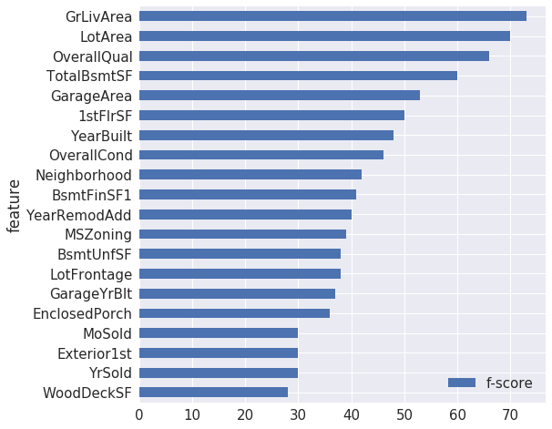

```python
#plot top 20 important#plot to
importance = final_gb.get_fscore()
importance_df = pd.DataFrame({'feature':list(importance.keys()), 'f-score':list(importance.values())})
importance_df = importance_df.sort_values('f-score')[-20:]
sns.set(font_scale = 1.5)
importance_df.plot(kind = 'barh', x = 'feature', figsize = (8,8))
```

```
Text(0.5,0.98,'Test Actual vs. Prediction')
```

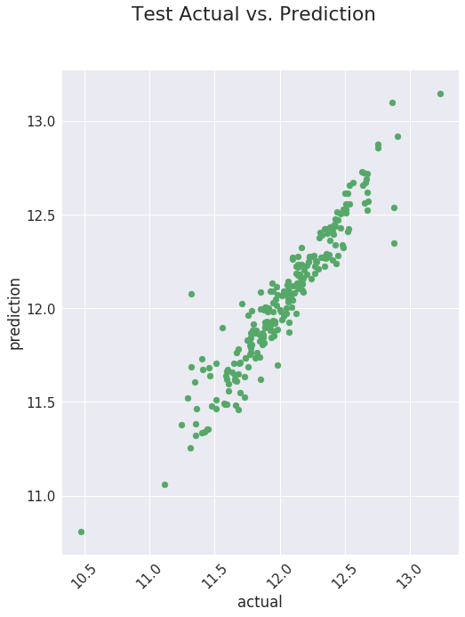

```python
xgdmat_test = xgb.DMatrix(X_val)
pred_test = final_gb.predict(xgdmat_test)
#Test actual vs prediction
plt.scatter(Y_val, pred_test,  color='g')
plt.xlabel('actual')
plt.xticks(rotation = 45)
plt.ylabel('prediction')
plt.suptitle('Test Actual vs. Prediction')
```

```python
from sklearn.metrics import accuracy_score
#pred_test[pred_test > 0.5] = 1
#pred_test[pred_test <= 0.5] = 0
predictions = [round(value) for value in pred_test]
y_val=[round(value) for value in Y_val]
accuracy_score( y_val, predictions), 1-accuracy_score(y_val, predictions)
```

```
(0.9041666666666667, 0.09583333333333333)
```

```python
res0 = np.sqrt(np.mean((pred_test-Y_val)**2))
print("RMSE Mean on train data:",res0)

# res1 = rmse_test(xgboost_model)
# print("RMSE Mean on test data:",res1.mean())
# print("RMSE Min on test data: ",res1.min())
```

```
RMSE Mean on train data: 0.12207760375023294
```

## REGULARZATION

Regularization is a form of regression that constrains or regularizes the coefficient estimates towards zero. It prevents overfitting by constraining the complexity of the model learnt. The loss function in regularization fitting is the residual sum of squares (RSS). The coefficients are chosen such that they minimize the loss. Regularization handles noisy training data by constraining the learned estimates towards zero.

### IV.4 BAYESIAN RIDGE REGRESSION Go to content Table

Ridge regression performs L2 regularization where it adds a penalty equivalent to the square of magnitude of coefficients `alpha`. This optimization is done to minimize the sum of RSS and alpha. Here, $\alpha$ is the tuning parameter which balances the amount of emphasis given to minimising RSS vs minimising sum of square of coefficients. It can take various values:  
When $\alpha = 0$; the objective becomes same as simple linear regression. When $\alpha = \infty$, the coefficients are zero which will inturn make the objective infinite.  
A magnitude of $\alpha$ between 0 and $\infty$ determines the weight assigned to the objective. Ridge is majorly used to prevent overfitting. Since it includes all the features, it is not very useful in case of exorbitantly high features, say in millions, as it will pose computational challenges.

```python
# Create linear regression object
regBR = linear_model.BayesianRidge(alpha_2=1)

# Train the model using the training sets
model = regBR.fit(X_train, Y_train)

# Make predictions using the testing set
Saleprice_pred_baye = np.exp(regBR.predict(X_val))


print("Score:", model.score(X_val, Y_val) )

## The line / model
plt.scatter(Y_val, Saleprice_pred)
plt.show()

#  The root mean squared error
print("Root mean squared error: %.8f"
       % np.sqrt(mean_squared_error(Y_val, Saleprice_pred)))
#Explained variance score: 1 is perfect prediction
print('Variance score: %.8f' % r2_score(Y_val, Saleprice_pred))
```

[output not shown]

```
Score: 0.8901501724695025
```

```
Root mean squared error: 0.13105306
Variance score: 0.88324736
```

### IV.3 LASSO MODEL Go to content Table

LASSO stands for *Least Absolute Shrinkage and Selection Operator*. Lasso regression performs L1 regularization, i.e. it adds a factor of sum of absolute value of coefficients in the optimisation objective. Here, $\alpha$ works similar to that of ridge where it can take various values and provide a trade-off between balancing RSS and magnitude of coefficients.  
LASSO provides sparse solutions, it is generally the model of choice (or some variant of this concept) for modelling cases where the features are in millions or more. In such a case, getting a sparse solution is of great computational advantage as the features with zero coefficients can simply be ignored.  
The advantage of LASSO over Ridge is that, along with shrinking coefficients, LASSO performs feature selection as well.  
Since some of the coefficients become exactly zero, which is equivalent to the particular feature being excluded from the model. With Ridge, it includes all (or none) of the features in the model. Thus, the major advantage of ridge regression is coefficient shrinkage and reducing model complexity.

```python
#now create our object
model_lasso = LassoCV(alphas = [1, 0.1, 0.001, 0.0005], selection='random', normalize=True, max_iter=15000).fit(X_train, Y_train)
res1 = rmse_test(model_lasso)

#test data RMSE
print("RMSE Mean on test data:",res1.mean())
print("RMSE Min on test data: ",res1.min())
```

```
RMSE Mean on test data: 0.13491843175497
RMSE Min on test data:  0.08322204710544553
```

```python
coef = pd.Series(model_lasso.coef_, index = X_train.columns)
print("Lasso picked " + str(sum(coef != 0)) + " variables and eliminated the other " +  str(sum(coef == 0)) + " variables")
```

```
Lasso picked 29 variables and eliminated the other 50 variables
```

```
Text(0.5,1,'Coefficients in the Lasso Model')
```

[figure not shown]

```python
# plotting feature importances!
imp_coef = pd.concat([coef.sort_values().head(10),
                     coef.sort_values().tail(10)])
matplotlib.rcParams['figure.figsize'] = (8.0, 10.0)
imp_coef.plot(kind = "barh")
plt.title("Coefficients in the Lasso Model")
```

```python
# Make predictions using the testing set
Saleprice_pred_lasso = np.exp(model_lasso.predict(X_val))
## The line / model
plt.scatter(Y_val, Saleprice_pred)
plt.show()
```

[output not shown]

### IV.5 RANDOM FORESTS Go to content Table

**Random Forest Regressor** algorithm works as follows:  
At every node, all of the features are evaluated for the best split. A best split is the one that gives the least weighted mean square error between actual price of the samples and the predicted price in the nodes it split into. The predicted price is just the average of the prices of all the samples in that node.  
Each node always splits into two other nodes. The parameters for the random forest regressor are as follows:

- The depth of tree (levels) can be specified in scikit-learn for `RandomForestRegressor` as `max_depth`.
- `min_samples_leaf` is the minimum number of samples that must be present in each node of the tree. This is specified to limit overfitting. If a large number is provided, the tree will only split such that the final leaf nodes contain at least
- `min_samples_leaf` number of samples.
- `max_features` is another parameter that can be specified to limit overfitting. If `max_features` is 0.5, only a random half of all the features are considered and evaluated for finding the best split.
- `n_estimators` is the parameter to specify number of trees. It is always better to have a large number of trees but it may become computationally expensive. It is normal to have hundreds of trees. When analyzing and tuning for the hyperparameters, usual practice is to use 10–40 trees.
- `n_jobs` is the number of cores of CPU the algorithm runs upon to parallelize. A value of -1 means that the algorithm uses all the available CPU cores.

```python
#defining and fitting the random forest model
regRF = RandomForestRegressor()
modelRF = regRF.fit(X_train, Y_train)
```

```
Score: 0.8503317596594056
```

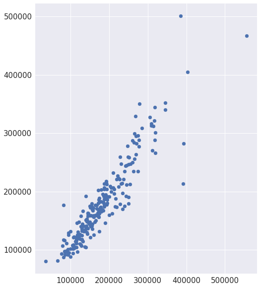

```
RMSE Mean on test data: 0.1778486967621748
RMSE Min on test data:  0.12171655576115739
```

```python
#making predictions using the random forest model
Sale_Price_Pred_RF = np.exp(regRF.predict(X_val))

#printing the score
print("Score:", modelRF.score(X_val, Y_val) )

## The line / model
plt.scatter(np.exp(Y_val), Sale_Price_Pred_RF)
plt.show()

#RMSE on validation data
rootMeanSquaredError = rmse_test(modelRF)
print("RMSE Mean on test data:",rootMeanSquaredError.mean())
print("RMSE Min on test data: ",rootMeanSquaredError.min())
```

### Applying Lasso Model

Lasso implements L1 regularization which prevents overfitting. The advantage of this method is that along with shrinking coefficients, LASSO performs feature selection as well. Although we see a better rmse for XGBoost than for Lasso, we choose to retain lasso because of its ability to prevent overfitting; which should be considered as a possibility when used for predicting unknown test data.

```python
#extracting the test data from all data created before
X_test = obj_df.iloc[train_df.shape[0]:,:]

#using lasso
Saleprice_Pred_lasso = np.exp(model_lasso.predict(X_test))
```

# Creating the submission file

```python
#a dictionnary with the Ids and the corresponding predicted SalePrice to generate a DataFrame
d={'Id': test_df['Id'], 'SalePrice': Saleprice_Pred_lasso}
#creating a dataFrame from the dictionnary above
submission_file= pd.DataFrame(data=d)
```

```python
#saving the submission file in our current directory into a csv file named submission_file.csv (index is set to False to ignore row index)
submission_file.to_csv("submission_file", index=False)
```